# Time Series Practice

M. Affouf

April 6, 2018

# Time Series Analysis

### Creating and examining date objects

The base R package provides date functionality. This grab-bag recipe shows you several date-related operations in R. R internally represents dates as the number of days from 1 January, 1970.

```r
#Internally, R represents dates as the number of days from 1 January, 1970:
#1. Get today's date:

 Sys.Date()
```

```
## [1] "2018-04-08"
```

```r
#2. Create a date object from a string:
 # Supply year as two digits
 # Note correspondence between separators in the date string and the format string

as.Date("1/1/80", format = "%m/%d/%y")
```

```
## [1] "1980-01-01"
```

```r
 # Supply year as 4 digits
 # Note uppercase Y below instead of lowercase y as above

 as.Date("1/1/1980", format = "%m/%d/%Y")
```

```
## [1] "1980-01-01"
```

```r
 # If you omit format string, you must give date as "yyyy/mm/dd" or as "yyyy-mm-dd"

 as.Date("1970/1/1")
```

```
## [1] "1970-01-01"
```

```r
 as.Date("70/1/1")
```

```
## [1] "0070-01-01"
```

```r
#3. Use other options for separators (this example uses hyphens) in the format string, and also see the underlying numeric value:

 dt <- as.Date("1-1-70", format = "%m-%d-%y")
 as.numeric(dt)
```

```
## [1] 0
```

```r
#4. Explore other format string options:

 as.Date("Jan 15, 2015", format = "%b %d, %Y")
```

```
## [1] "2015-01-15"
```

```r
 as.Date("January 15, 15", format = "%B %d, %y")
```

```
## [1] "2015-01-15"
```

```r
#5. Create dates from numbers by typecasting:

 dt <- 1000
 class(dt) <- "Date"
 dt # 1000 days from 1/1/70
```

```
## [1] "1972-09-27"
```

```r
 dt <- -1000
 class(dt) <- "Date"
 dt # 1000 days before 1/1/70
```

```
## [1] "1967-04-07"
```

```r
#6. Create dates directly from numbers by setting the origin date:

 as.Date(1000, origin = as.Date("1980-03-31"))
```

```
## [1] "1982-12-26"
```

```r
 as.Date(-1000, origin = as.Date("1980-03-31"))
```

```
## [1] "1977-07-05"
```

```r
#7. Examine date components:

 dt <- as.Date(1000, origin = as.Date("1980-03-31"))
 dt
```

```
## [1] "1982-12-26"
```

```r
 # Get year as four digits
 format(dt, "%Y")
```

```
## [1] "1982"
```

```r
 # Get the year as a number rather than as character string

 as.numeric(format(dt, "%Y"))
```

```
## [1] 1982
```

```r
 # Get year as two digits
 format(dt, "%y")
```

```
## [1] "82"
```

```r
 # Get month
 format(dt, "%m")
```

```
## [1] "12"
```

```r
 as.numeric(format(dt, "%m"))
```

```
## [1] 12
```

```r
 # Get month as string
 format(dt, "%b")
```

```
## [1] "Dec"
```

```r
 format(dt, "%B")
```

```
## [1] "December"
```

```r
 months(dt)
```

```
## [1] "December"
```

```r
 weekdays(dt)
```

```
## [1] "Sunday"
```

```r
 quarters(dt)
```

```
## [1] "Q4"
```

```r
  julian(dt)
```

```
## [1] 4742
## attr(,"origin")
## [1] "1970-01-01"
```

```r
julian(dt, origin = as.Date("1980-03-31"))
```

```
## [1] 1000
## attr(,"origin")
## [1] "1980-03-31"
```

The following table summarizes the formatting options for the components of the date:

| Format specifier | Description |
| --- | --- |
| %d | Day of month as a number-for example, 15 |
| %m | Month as a number-for example, 10 |
| %b | Abbreviated string representation of month-for example, “Jan” |
| %B | Complete string representation of month-for example,“January” |
| %y | Year as two digits-for example, 87 |
| %Y | Year as four digits-for example, 2001 |

### Operating on date objects

```r
#1. Perform the addition and subtraction of days from date objects:
 dt <- as.Date("1/1/2001", format = "%m/%d/%Y")
 dt
```

```
## [1] "2001-01-01"
```

```r
 dt + 100 # Date 100 days from dt
```

```
## [1] "2001-04-11"
```

```r
 dt + 31
```

```
## [1] "2001-02-01"
```

```r
#2. Subtract date objects to find the number of days between two dates:
 dt1 <- as.Date("1/1/2001", format = "%m/%d/%Y")
 dt2 <- as.Date("2/1/2001", format = "%m/%d/%Y")
 dt1-dt1
```

```
## Time difference of 0 days
```

```r
 dt2-dt1
```

```
## Time difference of 31 days
```

```r
 dt1-dt2
```

```
## Time difference of -31 days
```

```r
 as.numeric(dt2-dt1)
```

```
## [1] 31
```

```r
#3. Compare date objects:
 dt2 > dt1
```

```
## [1] TRUE
```

```r
 dt2 == dt1
```

```
## [1] FALSE
```

```r
#4. Create date sequences:
 d1 <- as.Date("1980/1/1")
 d2 <- as.Date("1982/1/1")
 # Specify start date, end date and interval
 seq(d1, d2, "month")
```

```
##  [1] "1980-01-01" "1980-02-01" "1980-03-01" "1980-04-01" "1980-05-01"
##  [6] "1980-06-01" "1980-07-01" "1980-08-01" "1980-09-01" "1980-10-01"
## [11] "1980-11-01" "1980-12-01" "1981-01-01" "1981-02-01" "1981-03-01"
## [16] "1981-04-01" "1981-05-01" "1981-06-01" "1981-07-01" "1981-08-01"
## [21] "1981-09-01" "1981-10-01" "1981-11-01" "1981-12-01" "1982-01-01"
```

```r
 d3 <- as.Date("1980/1/5")
 seq(d1, d3, "day")
```

```
## [1] "1980-01-01" "1980-01-02" "1980-01-03" "1980-01-04" "1980-01-05"
```

```r
 # more interval options
 seq(d1, d2, "2 months")
```

```
##  [1] "1980-01-01" "1980-03-01" "1980-05-01" "1980-07-01" "1980-09-01"
##  [6] "1980-11-01" "1981-01-01" "1981-03-01" "1981-05-01" "1981-07-01"
## [11] "1981-09-01" "1981-11-01" "1982-01-01"
```

```r
 # Specify start date, interval and sequence length
 seq(from = d1, by = "4 months", length.out = 4 )
```

```
## [1] "1980-01-01" "1980-05-01" "1980-09-01" "1981-01-01"
```

```r
#5. Find a future or past date from a given date, based on an interval:
 seq(from = d1, by = "3 weeks", length.out = 2)[2]
```

```
## [1] "1980-01-22"
```

```r
# Example
BD<- as.Date("2005/2/1")
BD
```

```
## [1] "2005-02-01"
```

```r
weekdays(BD)
```

```
## [1] "Tuesday"
```

```r
DN<- Sys.Date()
DN
```

```
## [1] "2018-04-08"
```

```r
#Age in days
DN-BD
```

```
## Time difference of 4814 days
```

### Performing preliminary analyses on time series data

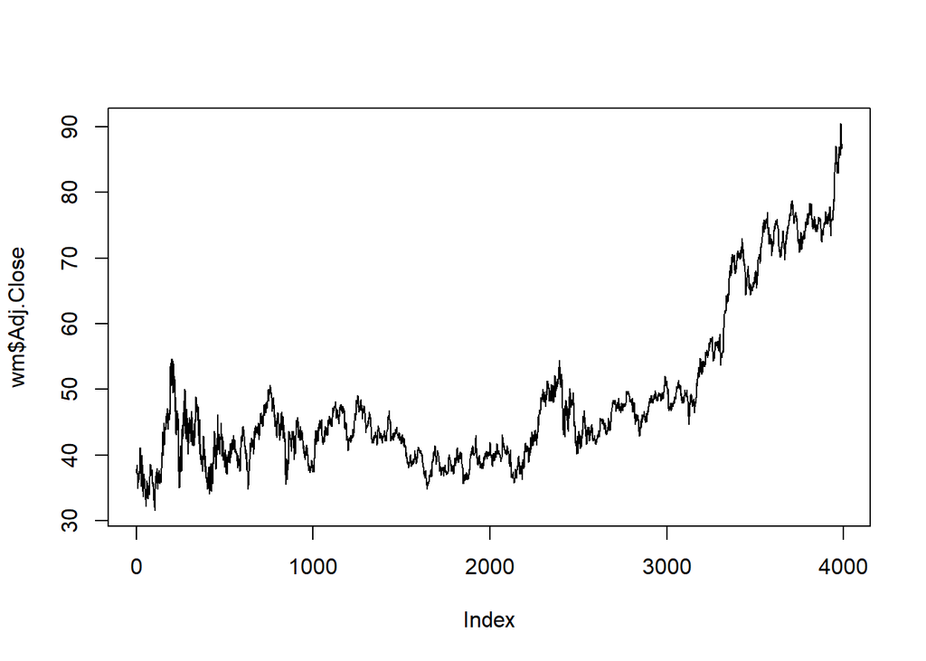

```r
#1. Read the file. We will use a data file that has the share prices of Walmart (downloaded)
 wm <- read.csv("walmart.csv")
# 2. View the data as a line chart:
 plot(wm$Adj.Close, type = "l")
```

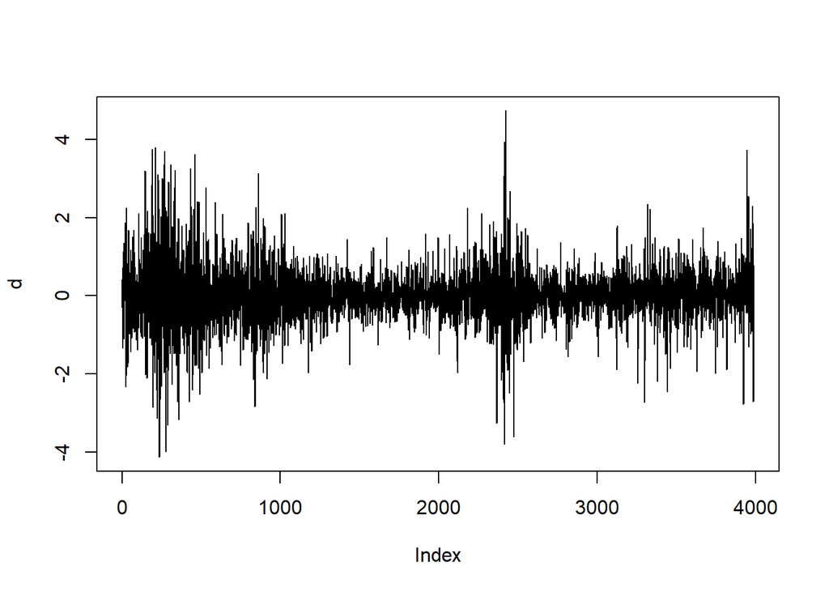

```r
#3. Compute and plot daily price movements:
 d <- diff(wm$Adj.Close)
 plot(d, type = "l")
```

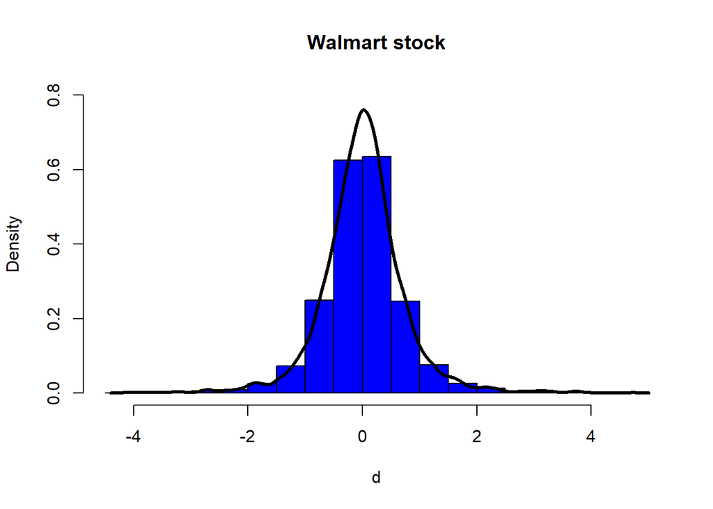

```r
#4. Generate a histogram of the daily price changes, along with a density plot:
 hist(d, prob = TRUE, ylim = c(0,0.8), main = "Walmart stock", col = "blue")
 lines(density(d), lwd = 3)
```

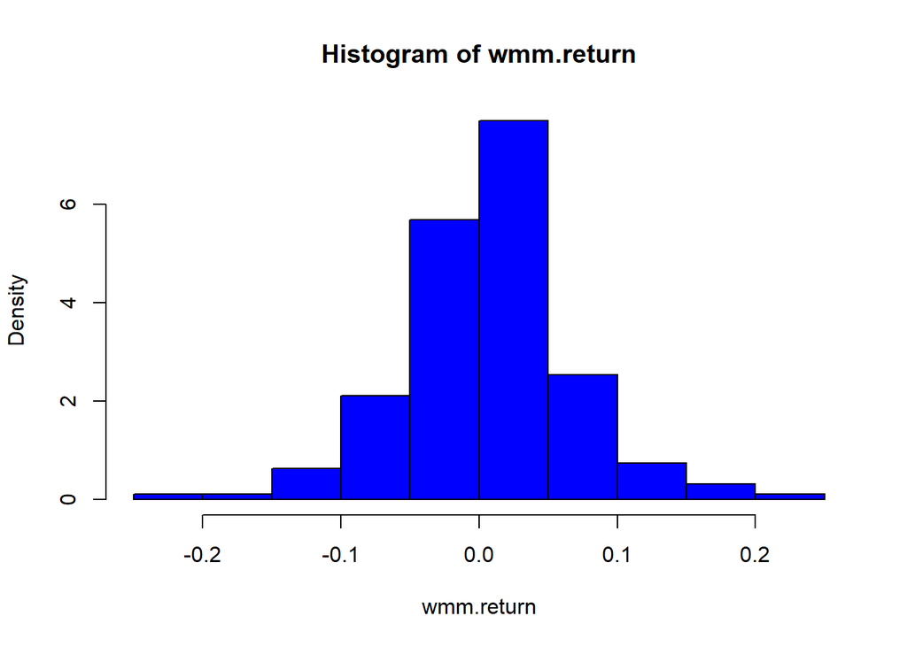

```r
#5. Compute one-period returns:
 wmm <- read.csv("walmart-monthly.csv")
 wmm.ts <- ts(wmm$Adj.Close)
 d <- diff(wmm.ts)
 wmm.return <- d/lag(wmm.ts, k=-1)
 hist(wmm.return, prob = TRUE, col = "blue")
```

- Step 1 reads the data and step 2 plots it as a line chart.
- Step 3 uses the diff function to generate single-period differences. It then uses the plot function to plot the differences. By default, the diff function computes single-period differences. You can use the lag argument to compute differences for greater lags. For example, the following calculates two-period lagged differences:

`diff(wmm$Adj.Close, lag = 2)`

- Step 4 generates a histogram of one-period price changes. It uses prob=TRUE to generate a histogram based on proportions, and then adds on a density plot as well to give a higher-granularity view of the shape of the distribution.
- Step 5 computes one-period returns for the stock. It does this by dividing the one-period differences by the stock value at the first of the two periods that the difference is based on. It then generates a histogram of the returns.

### Using time series objects

```r
#1. Read the data. The file has 100 rows and a single column named sales:
 s <- read.csv("ts-example.csv")
#2. Convert the data to a simplistic time series object without any explicit notion of time:
 s.ts <- ts(s)
 class(s.ts)
```

```
## [1] "ts"
```

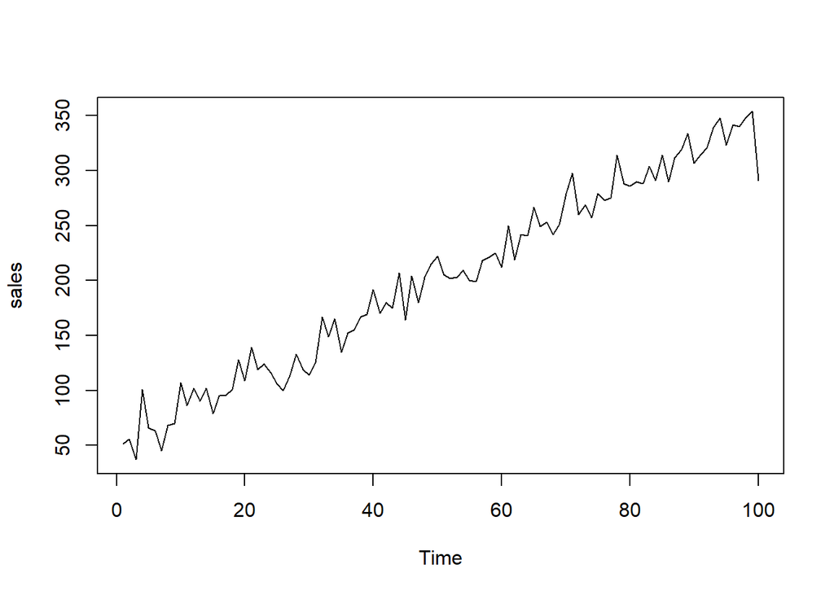

```r
#3. Plot the time series:
 plot(s.ts)
```

```r
#4. Create a proper time series object with time points:
 s.ts.a <- ts(s, start = 2002)
 head(s.ts.a)
```

```
## [1]  51  56  37 101  66  63
```

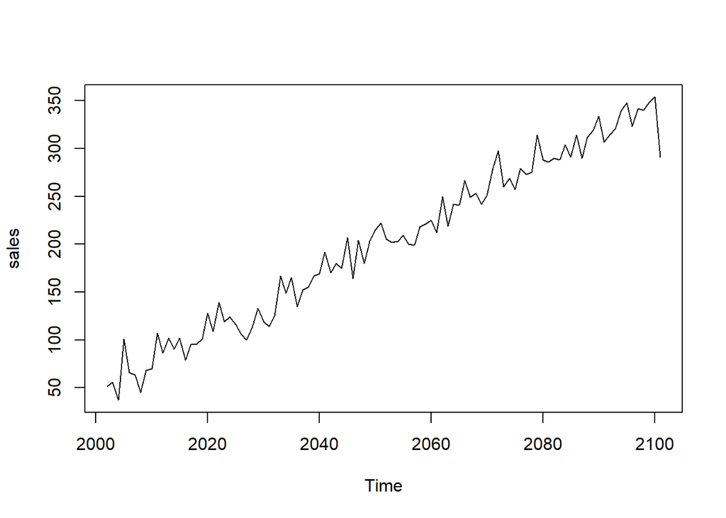

```r
 plot(s.ts.a)
```

```r
 # results show that R treated this as an annual
 # time series with 2002 as the starting year
 # Create a monthly time series
 s.ts.m <- ts(s, start = c(2002,1), frequency = 12)
 s.ts.m
```

```
##      Jan Feb Mar Apr May Jun Jul Aug Sep Oct Nov Dec
## 2002  51  56  37 101  66  63  45  68  70 107  86 102
## 2003  90 102  79  95  95 101 128 109 139 119 124 116
## 2004 106 100 114 133 119 114 125 167 149 165 135 152
## 2005 155 167 169 192 170 180 175 207 164 204 180 203
## 2006 215 222 205 202 203 209 200 199 218 221 225 212
## 2007 250 219 242 241 267 249 253 242 251 279 298 260
## 2008 269 257 279 273 275 314 288 286 290 288 304 291
## 2009 314 290 312 319 334 307 315 321 339 348 323 342
## 2010 340 348 354 291
```

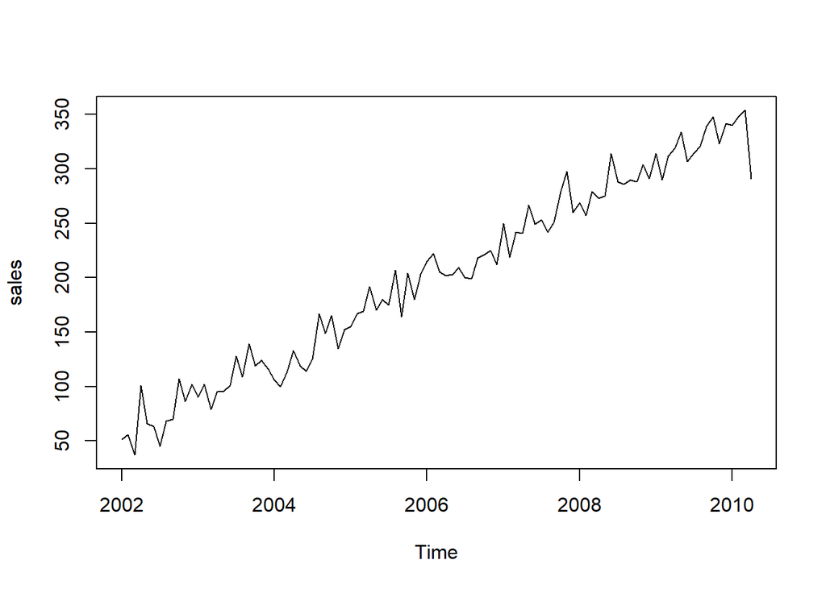

```r
plot(s.ts.m) # note x axis on plot
```

```r
 # Specify frequency = 4 for quarterly data
 s.ts.q <- ts(s, start = 2002, frequency = 4)
 s.ts.q
```

```
##      Qtr1 Qtr2 Qtr3 Qtr4
## 2002   51   56   37  101
## 2003   66   63   45   68
## 2004   70  107   86  102
## 2005   90  102   79   95
## 2006   95  101  128  109
## 2007  139  119  124  116
## 2008  106  100  114  133
## 2009  119  114  125  167
## 2010  149  165  135  152
## 2011  155  167  169  192
## 2012  170  180  175  207
## 2013  164  204  180  203
## 2014  215  222  205  202
## 2015  203  209  200  199
## 2016  218  221  225  212
## 2017  250  219  242  241
## 2018  267  249  253  242
## 2019  251  279  298  260
## 2020  269  257  279  273
## 2021  275  314  288  286
## 2022  290  288  304  291
## 2023  314  290  312  319
## 2024  334  307  315  321
## 2025  339  348  323  342
## 2026  340  348  354  291
```

```r
#5. Query time series objects (we use the s.ts.m object we created in the previous step):
 # When does the series start?
 start(s.ts.m)
```

```
## [1] 2002    1
```

```r
 # When does it end?
 end(s.ts.m)
```

```
## [1] 2010    4
```

```r
 # What is the frequency?
 frequency(s.ts.m)
```

```
## [1] 12
```

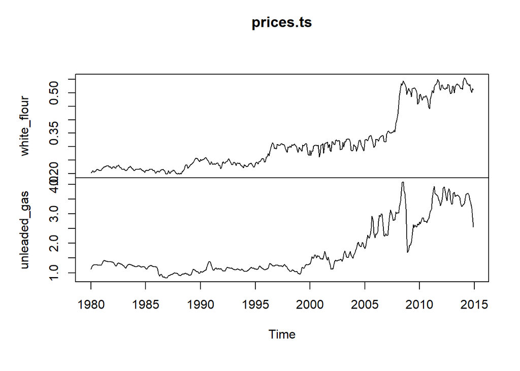

```r
#6. Create a time series object with multiple time series. This data file contains US monthly consumer prices for white flour and unleaded gas for the years 1980 through 2014 (downloaded from the website of the US Bureau of Labor Statistics):
 prices <- read.csv("prices.csv")
 prices.ts <- ts(prices, start=c(1980,1), frequency = 12)
#7. Plot a time series object with multiple time series:
 plot(prices.ts)
```

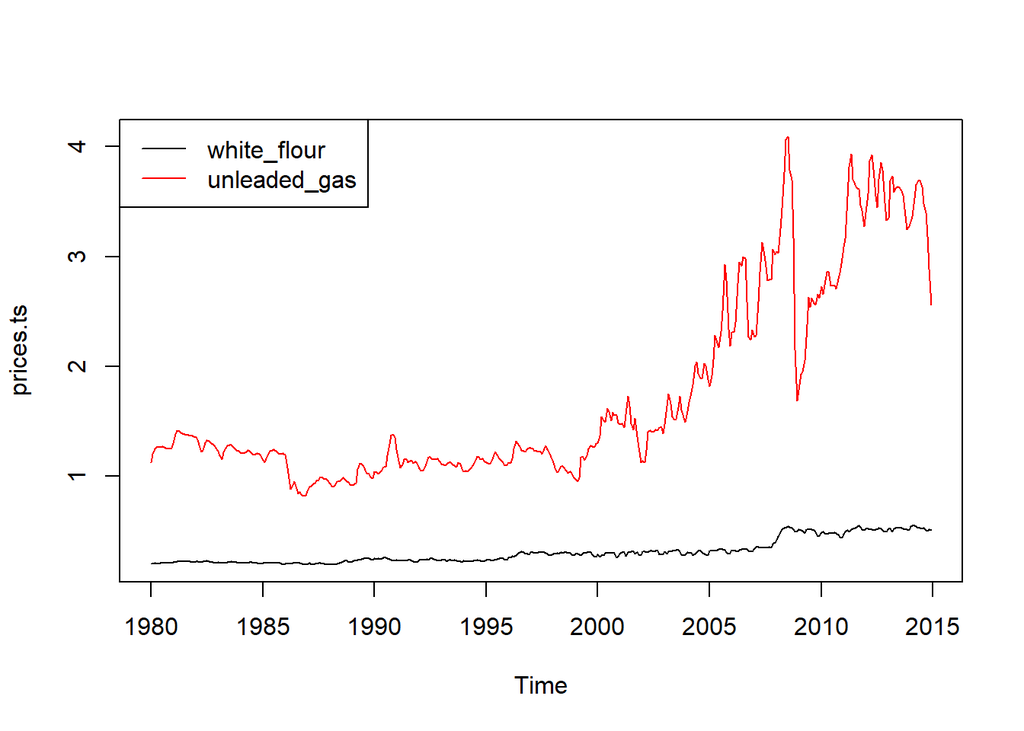

```r
 # Plot both series in one panel with suitable legend
 plot(prices.ts, plot.type = "single", col = 1:2)
 legend("topleft", colnames(prices.ts), col = 1:2, lty = 1)
```